# Predicting Illegal Rentals in Philadelphia

Jessica Klion, Fay Walker, and Hyo Sung (Angelica) Kim

[Return to MUSA 801 Projects Page](https://pennmusa.github.io/MUSA_801.io/)

# 1.0 Introduction

### 1.1 How to use this document

This project was produced as part of the University of Pennsylvania’s Master of Urban Spatial Analytics Spring 2018 Practicum (MUSA 801) taught by Ken Steif, Michael Fichman, and Matt Harris. We would like to thank Jonathan Pyle of Philadelphia Legal Assistance for providing feedback and data.

The following document presents an analysis of illegal rentals in Philadelphia and an interactive tool for the Philadelphia Department of Licenses and Inspections (L&I) that will ultimately help proactively prioritize inspections to stymy illegal rentals before they turn into illegal evictions. The tool will provide a risk score for every rental property in the city, indicating each property’s likelihood of being rented illegally. This document includes a detailed overview of the use case, analysis and key findings, as well as the relevant code needed to replicate the analysis.

### 1.2 Abstract

In Philadelphia, all rental units are required to be certified prior to leasing. Through certification, landlords must obtain a rental license, at a cost of about $55 annually. If a unit is not certified, but is still rented out, it is considered an illegal rental. If a landlord is renting illegally, then any subsequent tenant eviction is also illegal, meaning the tenant has no legal recourse.

With no official record of the rental and the eviction, it is difficult to distill how often landlords are renting out their properties illegally. The only record we have for illegal rentals is the Department of Licenses and Inspections (L&I) Code Violation 9-3902; renting without a license, but this number is far underestimating the problem.

Currently, L&I conducts inspections reactively, according to received 311 complaints. However, L&I only employs 17 inspectors, and there is a backlog of complaints still to be inspected. A statistical model that can predict property-specific illegal rental risk would allow L&I to proactively address illegal rentals before they turn into illegal evictions. This tool predicts the likelihood that a property is being rented to a tenant without a rental license for all non-owner occupied homes in Philadelphia to help L&I prioritize inspections more efficiently.

### 1.3 Motivation

Between 2005 to 2016, rental prices in Philadelphia went up by 10 percent, while wages only went up by 0.3 percent. As a result, over half of Philadelphia renters are rent-burdened (spending over one-third of income on housing), and nearly one-third of these renters spend over 50 percent of their salary on housing.

#### Figure 1. Median rent over time in Philadelphia

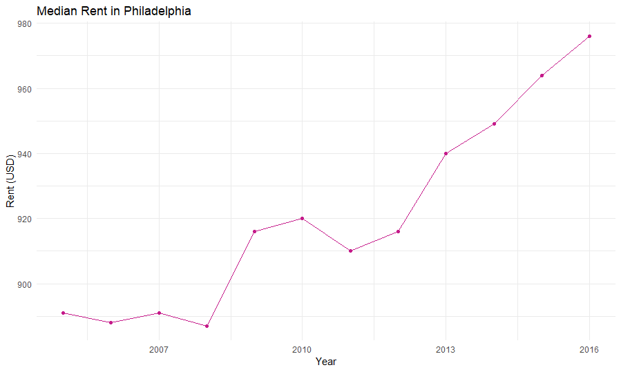

*Source: American Community Survey 2012-2016*

In 2016 alone, there were 24,000 evictions, impacting 9 percent of households in Philadelphia. Evictions bear real implications, particularly because they impact already vulnerable populations, including single-mothers, low-income, and black households disproportionately (Mayor’s Taskforce on Eviction Prevention and Response, June 2018).

#### Figure 2. Inequity of evictions in Philadelphia

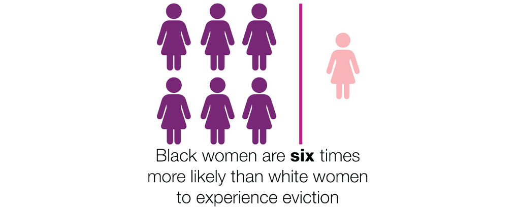

*Source: Mayor’s Task Force on Eviction and Prevention, June 2018*

As rental prices rise and evictions increase in frequency, so too does homelessness. There are an estimated 5,700 homeless people in Philadelphia, and about 20 percent of people in shelters list eviction as the primary cause of their homelessness.

Evictions are a pressing issue, so much so that Mayor Jim Kenney established the Mayor’s Task Force for Eviction Prevention and Response in September 2017. One action item from the taskforce was to gain a better understanding of illegal rentals, and by extension, illegal evictions in the city.

Our illegal rental predictive model uses a data-driven approach that would allow L&I to proactively address illegal rentals before they turn into illegal evictions, and utilize their limited resources more efficiently. Catching illegal rentals before they turn into illegal evictions protects tenants because legal evictions prohibit landlords from locking tenants out, require landlords to provide eviction notice, and ensure a court process. The true number of illegal evictions is unknowable, but curbing illegal rental violations serves as a concrete way for the city to begin addressing housing insecurity and homelessness.

# 2.0 Data Wrangling and Cleaning

This analysis was built off of publicly available data, largely from Philadelphia’s open data portal. Philadelphia Community Legal Services also provided us with scraped eviction docket data. Because we were working with messy administrative data, our primary data wrangling challenge was to bringing and cleaning the following datasets together into one dataset:

- Property Assessments (from the Office of Property Assessment via OpenDataPhiladelphia)
- Licensing and Inspection Code Violations (from Licenses and Inspections via OpenDataPhiladelphia)
- Business Licenses (from Licenses and Inspections via OpenDataPhiladelphia)

Additional data was collected to inform both our exploratory analysis and our model development:

To make the data more manageable, data was limited to the years 2016-2018. Once the cleaning was complete, we were left with a dataset of about 305,000 individual parcels with over 200 variables.

Our final dataset included a “universe” of all potential rental properties in Philadelphia. We limited our data to only properties that we understood to not be owner-occupied because it would be a poor use of L&I’s limited resources to allocate time to inspecting properties for an illegal rental violation that are owner-occupied. We determined the universe of rental properties by filtering our dataset to only include properties zoned as residential and where no homestead (owner-occupied) tax exemption was claimed.

#### Figure 3. The universe of potential rental properties

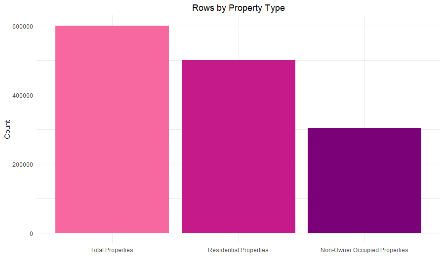

*Source: Office of Property Assessments, Open Data Philly, 2016-2018*

With our data coming from many sources, the properties in one dataset were not always included in another. As a result, when we joined the different datasets together, these properties, or rows, appear to be missing data. For example, if a property from the OPA dataset does not match with any properties from the violations dataset, based off of its OPA Account Number, we can assume that this property does not have a violation. It is important to note that any assumption will inevitably bias our data. Because across all of our datasets we assumed that missing data meant the absence of a matching property, we bias our data towards underestimating violations, licenses, and tax delinquencies.

#### Figure 4. Table of properties from each dataset

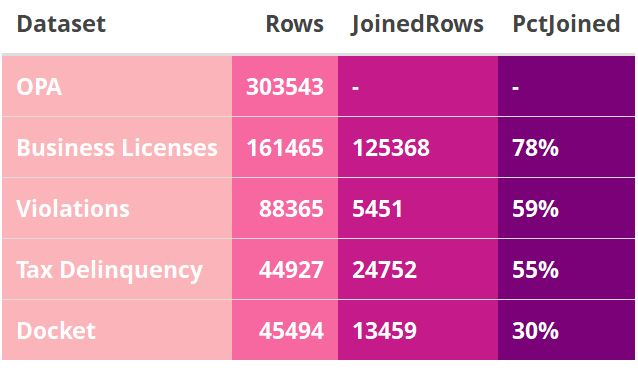

*Percentage of properties joined from cleaned datasets to OPA*

### 2.1 Data Stories and Feature Engineering

We sorted our data into four different “stories” that together paint a full picture of illegal rentals. These four stories are used to estimate an illegal rental risk score for each property city wide. This is done to ensure our model is sensitive to a diverse range of variables.

The dependent variable for our analysis - that is the variable we are trying to predict - is illegal rental violations, which we encode in our data as ‘0’ to represent properties that have not received an illegal rental violation and ‘1’ to represent properties that have received an illegal rental violation.

#### Story 1: Violation History

*Hypothesis 1: Is violation history correlated with illegal rentals?*

To determine each property’s violation history, we looked at the L&I violations dataset. We created variables indicating the status of a citation at a property (e.g. active or inactive), if a property had multiple citations (aside from illegal rental), if an owner had multiple citations (aside from illegal rental), and if a property had interior or exterior citations. Violations are an indicator that a landlord is willing to provide non-code compliant housing and has not necessarily abided by housing code in the past.

#### Story 2: Legal History

*Hypothesis 2: Are past legal events correlated with illegal rentals?*

To determine each property’s legal history, we looked at tax delinquency, the eviction docket, and business licenses. Using the docket data, we wanted to determine, who are the repeat offenders and where are there properties evicting multiple families. To do this, we aggregated evictions by landlord and by address to get an eviction count for every property and every landlord. This serves as a way for us to see whether landlords have legally evicted tenants in the past.

Using the tax delinquency data, we determined how much was owed in taxes and for how long. This serves as a proxy for a landlord that has not abided by legal processes in the past.

We also used the business license data to determine the status of rental licenses for every property, in order to see whether licenses had been allowed to lapse or consistently renewed, this also served as a legal compliance indicator.

#### Story 3: Housing Characteristics

*Hypothesis 3: Are housing characteristics correlated with illegal rentals?*

To determine the physical characteristics of a house that are correlated with illegal rentals, we looked almost exclusively at the OPA property dataset, which includes data on housing condition, size, features, value, and owner. The majority of the features required little manipulation. In the cases where there was significant amounts of missing data, we created a “dummy” column that tells our model to note that this variable is missing significant data.

#### Story 4: Geospatial and Demographics

*Hypothesis 4: Are geospatial and demographic characteristics correlated with illegal rentals?*

Because there is already extensive research on who is disproportionately impacted by eviction we wanted to see if these demographic characteristics were also linked to illegal rentals in Philadelphia. We used census data to create variables for all the populations we know to be disproportionately impacted by legal evictions (female-headed households, black households, low-income households), to see if that link held true for illegal evictions.

We also determined the average distance from each violation and each license to the closest five violations or licenses, respectively, as a proxy for spatial patterns in illegal renting. This variable shows us whether there are any clustering patterns to rental licenses or violations, the idea being that certain behaviors are contagious. If owners see other owners renting without a rental licenses, or see other illegal behavior, they may be more likely to mirror that behavior.

We also assigned each property to a neighborhood and council district to see if, at a different scale, there is geographic clustering of illegal rentals that varies from neighborhood to neighborhood or council district to council district.

# 3.0 Exploratory Analysis

Our exploratory analysis focuses on understanding the rental market in Philadelphia, with a primary focus on evictions and illegal rentals. Through our exploratory analysis, we answered the following questions:

- Where are evictions in Philadelphia, and how has that changed over time?
- Where are illegal rentals in Philadelphia, what types of properties are being illegally rented, and how has that changed over time?
- What is the correlation between key variables and illegal rentals?

### 3.1 Where are evictions in Philadelphia, and how has that changed over time?

Understanding where legal evictions are occurring is beneficial for understanding the nature of the rental market in Philadelphia, which ultimately provides insight into illegal rentals.

#### Figure 5. Eviction Frequency

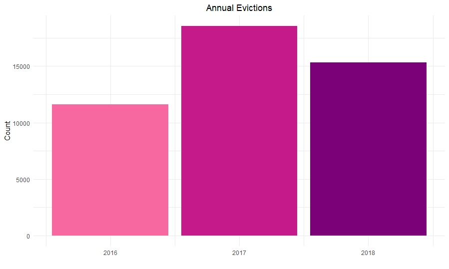

*Source: Court Docket, 2016-2018*

### 3.2 Where are illegal rentals in Philadelphia and what types of properties are being illegally rented?

Between 2016-2018, citations were given out for illegally renting a single-family home, illegally renting a multi-family home, and illegally renting a room, with the distribution heavily favoring single family homes.

#### Figure 6. Distribution of illegal rental violation types

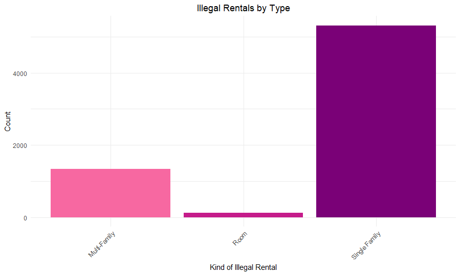

*Source: L&I, Open Data Philly, 2016-2018*

The density map below shows the distribution of illegal rental violations between 2016 and 2018 and compares it to the distribution of evictions over the same period. Evictions are more widespread across the city, however, there are similar hotspots in South and West Philadelphia.

#### Figure 7. Density of illegal rental violations

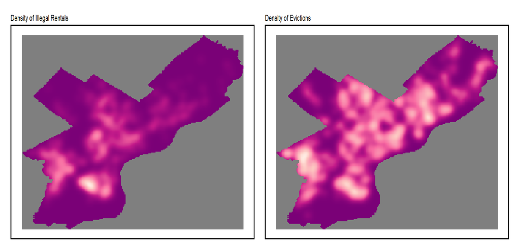

*Source: L&I, Open Data Philly, 2016-2018*

### 3.3 What is the relationship between key variables and illegal rentals?

Comparing homes with and without illegal rentals provides a strong basis for understanding the relationship between illegal rentals and explanatory variables. This allows us to see which variables see higher instances of illegal rental violations.

As the below charts show, illegal rentals are more prevalent in properties that have had interior and exterior violations, are tax delinquent, have out of state landlords, and are located on parcels with multiple units. However, they are less prevalent in properties built before 1900.

#### Figure 8. Relationship between variables and illegal rental violations

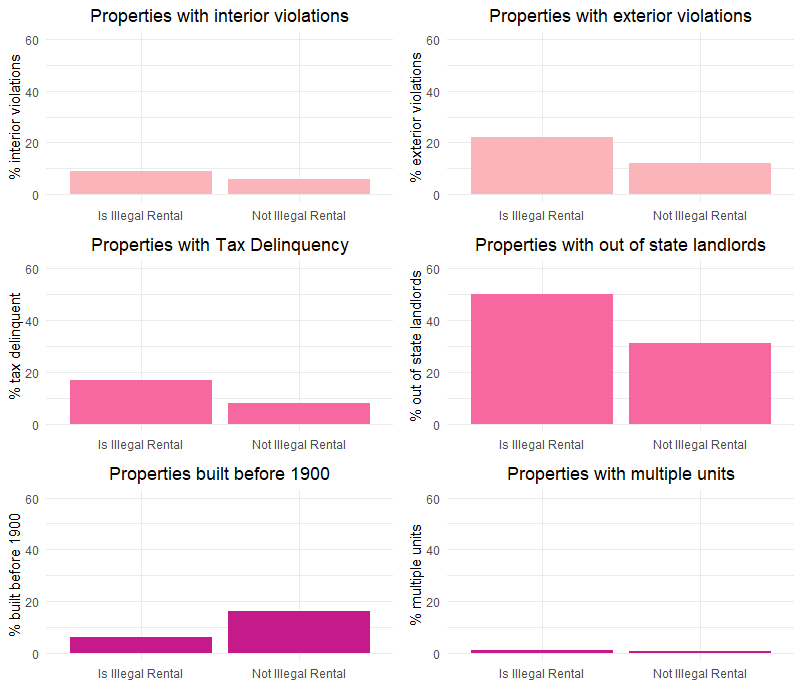

*Source: L&I, Office of Property Assessments,Department of Records, Open Data Philly*

Given that evictions disproportionately impact low income populations and people of color, understanding the relationship between these populations and illegal rental violations is also telling. The maps below show evictions, illegal rentals, tax delinquency, poverty, and minority populations by census tract. The data indicate that evictions and illegal rental violations are more prevalent in areas with higher minority and lower income populations.

#### Figure 9. Spatial distribution of demographic variables

[figure not shown]

*Source: ACS 2012-2016, Department of Records, Court Docket, L&I, Open Data Philly*

# 4.0 Modeling Strategy

The goal of our model is to learn from observed violations to predict a relative violation risk score for rental properties, including those homes that L&I does not regularly inspect. In order to ensure that certain data, namely the violation history, does not overpower our model, we used an ensemble model, which takes our four unique stories about violations, legal history, housing characteristics, and demographics and geospatial components and combines them into one model that weighs all four stories equally. Our model was validated using several metrics to ensure it is both accurate and generalizable.

### 4.1 Model Building

To build our predictive model we estimated separate models for each of the four stories and then ensembled them into one final predictive model. To determine what variables were most significant, we used stepwise selection. The stepwise model added and deleted variables one at a time so that we could see which variables are significant, but also how the variables correlate with each other. Through this process, we were able to winnow down our over 200 independent variables into 24 variables spread across four stories.

#### Figure 10. Four data stories

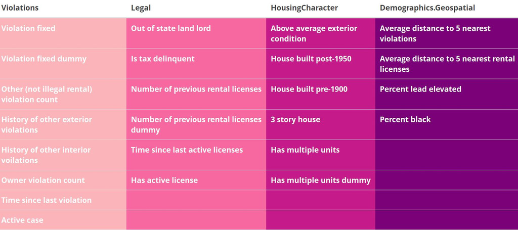

*Variables included in the four stories*

With our final variables determined, we then plugged these stories into the ensemble model, resulting in a relative risk score for rental properties in the City.

### 4.2 Validation

The predictive model provides an illegal rental risk score for all rental properties in Philadelphia. This risk score is used to classify properties as ‘worthy of inspection’ or ‘not worthy of inspection’ This ‘worthiness score’ provides a basis for measuring the accuracy and generalizability of our model.

While our continuous relative risk score is useful for L&I, we set a threshold to determine specified outcomes, listed in the table below. These outcomes allow for a more direct comparison of costs between our data driven approach and L&I’s business as usual.

#### Figure 11. Potential model outcomes

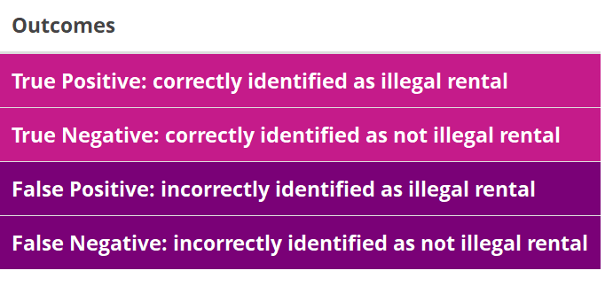

*Model outcomes*

We ultimately set the threshold at 0.65, which has a true positive rate of 80 percent and a true negative rate of 93 percent. At this threshold, the model has high true positive and true negative rates as well as low false negative and false positive rates, which have high social costs and burden L&I with unnecessary inspections. Note that this threshold is adjustable, depending on which outcome is most important to the user.

#### Figure 12. Model results

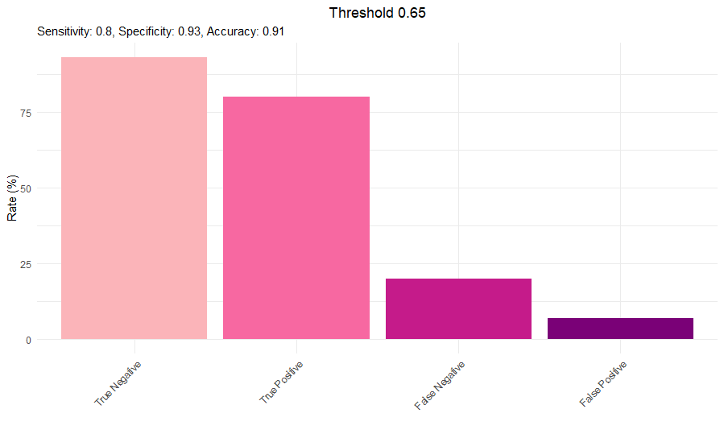

*Confusion matrix for final model*

#### Figure 13. ROC curve

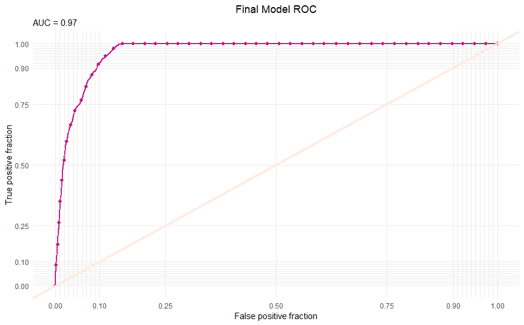

*ROC curve for the final model*

Our model has proven to be accurate, but does it predict equally well in different parts of the city? A generalizable model is imperative for creating a useful inspection tool for L&I, as the agency needs a tool that predicts as well in dense South Philly as it does in more suburban Northeast Philly. The below maps show the generalizability of the model.

#### Figure 14. Neighborhood level sensitivity and specificity

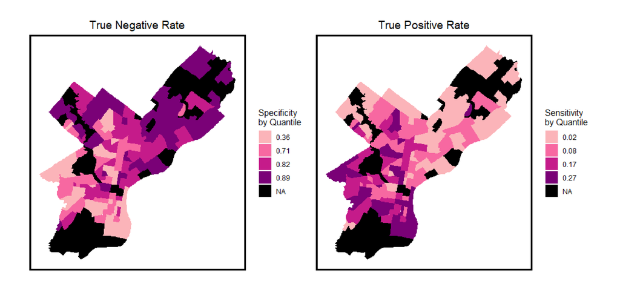

*Map of true positive and true negative rates by neighborhood*

True positive and true negative rates vary across neighborhoods. Our model does a better job of predicting true negative than true positives, this is unsurprising because there are far more negatives than positives. Geographically, our model fares best in predicting true negatives in the more suburban Northeast and Northwest and in predicting true positives in South and West Philadelphia. South and West Philadelphia have traditionally seen more disinvestment as compared to other parts of the city. Given this history, it would not be surprising for L&I to prioritize their inspections in these areas. It would then follow that where there are more inspections there are more illegal rental violations, both predicted and observed.

### 4.3 Cost Benefit Analysis

Ultimately, one of the key decision points in deciding between a data-driven approach and business as usual is the social and economic costs of both approaches. In other words, does our model help L&I use their resources more efficiently and does it reduce the high social cost of an illegal rental violation and an illegal eviction? To determine this we performed a cost benefit analysis, where we calculated a back of the envelope cost for all outcomes and compared this to the current cost of doing business for 1,000 properties.

We estimated the following costs:

- $1,180 for every true positive
- $50 for every true negative
- $50 for every false positive
- An unknown, but high social cost for every family displaced by a false negative

#### Figure 16. Aggregated costs and benefits

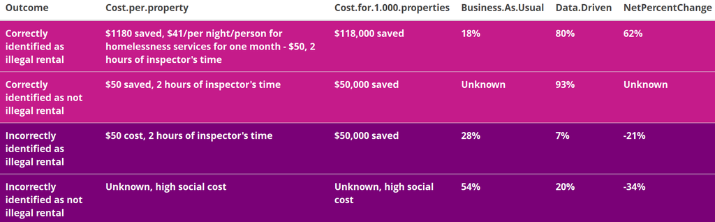

*Cost Benefit for Business as Usual vs. Data-Driven Approach*

When the rate of true positives, true negatives, false positives, and false negatives are compared, the data driven approach is more effective, thereby saving L&I money and avoiding the high social cost of false negatives.

# 5.0 Application and Interface

Our web-application allows L&I inspectors to identify parcels that have a high illegal rental risk score. Inspectors can open a map of Philadelphia and parcels with “high scores” will populate the map. The inspector can filter the parcels by the risk score so that they can prioritize and focus on inspecting homes with the highest risk. We chose to focus on Gray’s Ferry for this demonstration because it has the highest rate of illegal rentals.

Users can click on a parcel to get more information about the unit such as the risk score, unique parcel number (OPA account number), housing characteristics, legal and violation history, and inspection history. Because inspectors should prioritize inspection on properties that have been inspected less recently, we also included a slider that filters units according to last inspected date. Lastly, an interactive histogram changes to reflect the risk scores for the screen extent, so that inspectors can see if there are clusters of high priority risk scores and can efficiently prioritize not just individual units but also entire neighborhoods or areas.

# 6.0 Conclusions

There is a growing body of work that quantifies the far-reaching implications of formal evictions, however, illegal evictions remain an underreported phenomenon that impacts already disenfranchised communities. If Philadelphia wants to address their growing housing instability and curb evictions, the city must seek to curb illegal rentals before they turn into illegal evictions. Given L&I’s limited bandwidth, a data-driven approach to inspections provides the city with best practices on how to efficiently utilize limited funds and resources, while also increasing housing security for Philadelphia’s most vulnerable residents.

# 7.0 Code Appendix

The following shows the code used in this analysis. Section 7.1 covers data wrangling, feature engineering, and modeling. Section 7.2 covers the visuals created for this analysis.

### 7.1 Data Wrangling, Feature Engineering, and Modeling

First we set up our workspace.

```r
#load libraries

#load libraries
require(ggthemes)
require(IDPmisc)
library(corrplot)
library(stargazer)
library(sjPlot)
library(data.table)
library(ggplot2)
library(ggmap)
library(maps)
library(sp)
library(raster)
library(lattice)
library(latticeExtra)
library(RColorBrewer)
library(rasterVis)
library(dplyr)
library(stringr)
library(tidyverse)
library(tidyr)
library(stats)
library(data.table)
library(grid)
library(gridExtra)
library(rgdal)
library(sf)
library(lattice)
library(caret)
library(tidycensus)
library(FNN)
library(Rcpp)
library(viridisLite)
library(viridis)
library(jsonlite)
library(stringi)
library(downloader)
library(lubridate)
library(spdep)
library(randomForest)
library(kableExtra)


#remove scientific noation
options(scipen=999)
```

Next we began reading in our datasets, cleaning each dataset, and engineering features.

```r
##### OPA DATA #####

#read data

opa_orig<-fread('opa_properties_public.csv', header=TRUE, sep=",", colClasses='numeric')

#make copy
opafull<-opa_orig

#look for empties and NA's
colSums(opafull=='')
colSums(is.na(opafull))

#first cleaning of unecessary columns
opafull <- subset(opa_orig,select=-c(assessment_date,beginning_point,book_and_page,building_code_description,
                                  category_code_description, cross_reference, geographic_ward,
                                  house_number,market_value_date,objectid, parcel_shape, recording_date,
                                  registry_number, street_designation,street_direction,suffix,year_built_estimate,
                                  date_exterior_condition, mailing_address_1, mailing_address_2,mailing_care_of,
                                  building_code,category_code, owner_2,street_code))

sort(names(opafull))

#distribution of NA values across the datatset
colSums(is.na(opafull))

#distribution of empty values across the dataset
colSums(opafull=='')


##Narrow down opa dataset to possible rental houses

#by zoning code (those that begin with R)
opa1<- opafull %>% filter(str_detect(zoning, '^R'))

#by homestead exempt homes
sum(is.na(opa1$homestead_exemption)) #1270 NA
sum(opa1$homestead_exemption=='') #NA empties
#0 not exempt; 1 is exempt(=homeowners)
table(opa1$homestead_exemption)
#filter by 0, which are the not exempt units;
#consider NA's which we do not know, but assume is a non-exempt/rental
opa1 <- opa1 %>% filter(opa1$homestead_exemption == 0 | is.na(opa1$homestead_exemption))
table(opa1$homestead_exemption)
sum(is.na(opa1$homestead_exemption))

#OPA dataset cut down from 580k to 510k to 305k


#####################################################################################

#wrangling variables with empties

#basements
table(opa1$basements)

#create variables for basement types
opa1$basement_dummy <- ifelse(opa1$basements=='ZZ',1,0)
opa1$basement_none <- ifelse(opa1$basements=='No_Basement',1,0)
opa1$basement_full <- ifelse(opa1$basements == 'Full' , 1,0)
opa1$basement_partial <- ifelse(opa1$basements == 'Partial', 1,0)
opa1$basement_sizeNotKnown <- ifelse(opa1$basements == 'Size_Unknown', 1,0)

opa1$basement_dummy <- as.factor(opa1$basement_dummy)
opa1$basement_none <- as.factor(opa1$basement_none)
opa1$basement_full <- as.factor(opa1$basement_full)
opa1$basement_partial <- as.factor(opa1$basement_partial)
opa1$basement_sizeNotKnown <- as.factor(opa1$basement_sizeNotKnown)


#central_air
table(opa1$central_air)

#create variables for central air
opa1$central_air_dummy <- ifelse(opa1$central_air_new=='ZZ',1,0)
opa1$central_air_y <- ifelse(opa1$central_air_new==1,1,0)
opa1$central_air_n <- ifelse(opa1$central_air_new==0,1,0)

opa1$central_air_dummy <- as.factor(opa1$central_air_dummy)
opa1$central_air_y <- as.factor(opa1$central_air_y)
opa1$central_air_n <- as.factor(opa1$central_air_n)

#unfinished (u = unfinished/buildings under construction)
table(opa1$unfinished)

#create variables for unfinished buildings
opa1$unfinished_unit<-ifelse(opa1$unfinished=='',0,1)
opa1$unfinished_unit<-as.factor(opa1$unfinished_unit)


#unit (specific unit in condo, building complex, etc, where there are subproperties)
table(opa1$unit)

#create variable for unit type
#1-is a subunit; 0-not a subunit
opa1$unit_new <- ifelse(opa1$unit=='',0,1)
opa1$unit_new <- as.factor(opa1$unit_new)

#utility
table(opa1$utility)

#create variables for utility type
#1 - remodeled/modernized; 0 - no remodeling
opa1$utility_new <- ifelse(opa1$utility_new=='None',0,1)
opa1$utility_new <- as.factor(opa1$utility_new)

#garage type
table(opa1$garage_type)

#create variables for garage type
opa1$garage_type_dummy <- ifelse(opa1$garage_type_new=='ZZ',1,0)
opa1$garage_type_y <- ifelse(opa1$garage_type_new=='Has_Garage',1,0)
opa1$garage_type_n <- ifelse(opa1$garage_type_new=='None',1,0)

opa1$garage_type_dummy <- as.factor(opa1$garage_type_dummy)
opa1$garage_type_y <- as.factor(opa1$garage_type_y)
opa1$garage_type_n <- as.factor(opa1$garage_type_n)


#general construction type
table(opa1$general_construction)

#create variable for construction type
opa1$general_construction_dummy<-ifelse(opa1$general_construction_new=='ZZ',1,0)
opa1$general_construction_brickY<-ifelse(opa1$general_construction_new=='Common_Brick',1,0)
opa1$general_construction_brickN<-ifelse(opa1$general_construction_new=='Not_Common_Brick',1,0)

opa1$general_construction_dummy <- as.factor(opa1$general_construction_dummy)
opa1$general_construction_brickY <- as.factor(opa1$general_construction_brickY)
opa1$general_construction_brickN <- as.factor(opa1$general_construction_brickN)


#house_extension
table(opa1$house_extension)

#create variable for house extesnion
opa1$house_extension_n<-ifelse(opa1$house_extension_new=='No_Extension',1,0)
opa1$house_extension_n <- as.factor(opa1$house_extension_n)


#heater type
table(opa1$type_heater)

#heater Yes/No
opa1$type_heater_yn <- ifelse(opa1$type_heater=='','ZZ',
                              ifelse(opa1$type_heater=='0','NoHeater','HasHeater'))


#other building
table(opa1$other_building)

#create variable for other building
opa1$other_bldg_yn <- ifelse(opa1$other_building=='Y',1,0)
opa1$other_bldg_yn <- as.factor(opa1$other_bldg_yn)

#wrangling variables with NA's from the OPA dataset

#remove one row with several NA columns throughout - this should remove only one row
opa1 <- opa1[!is.na(opa1$number_of_bedrooms),]

#check
colSums(is.na(opa1))
colSums(opa1=='')


#exempt building; assuming NA is not exempt
table(opa1$exempt_building)

#make variable for exempt building
opa1$exempt_building_dummy <- ifelse(is.na(opa1$exempt_building),1,0)
opa1$exempt_building_y <- ifelse(is.na(opa1$exempt_building),0, ifelse(opa1$exempt_building==0,0,1))

opa1$exempt_building_dummy <- as.factor(opa1$exempt_building_dummy)
opa1$exempt_building_y <- as.factor(opa1$exempt_building_y)


#exempt land; assuming NA is not exempt
table(opa1$exempt_land)
```